# Exploratory Data Analysis

## Traffic Accidents in Berlin 2019

This notebook follows a data analysis of a dataset including all traffic accidents recorded in Berlin for the year 2019. The explanations for the used codes can be found here: https://www.statistik-berlin-brandenburg.de/opendata/AfSBBB_BE_LOR_Strasse_Strassenverkehrsunfaelle_2019_Datensatzbeschreibung.pdf

```python
import re
import os
import pandas as pd
import geopandas as gpd
import numpy as np
import matplotlib.pyplot as plt
import seaborn as sns
import scipy.stats as ss
from shapely.geometry import Point, Polygon
from matplotlib.colors import ListedColormap

#Set global plotting params.
%matplotlib inline
sns.set_style('darkgrid',
             rc={'axes.facecolor': '.9',
                 'grid.color': '.8'})
sns.set_palette('muted')
sns_c = sns.color_palette(palette='muted')
```

```python
plt.rcParams['figure.figsize'] = [10, 6]
```

```python
os.getcwd()
```

```
'/Users/maximiliankunz/Documents/PyScripts'
```

```python
# Read the data.
data = pd.read_csv('./accidents/AfSBBB_BE_LOR_Strasse_Strassenverkehrsunfaelle_2019_Datensatz.csv',
                  encoding='Latin1',
                  header=0,
                  sep=';')
```

```python
# First look.
data.head()
```

|  | OBJECTID | LAND | BEZ | LOR | STRASSE | UJAHR | UMONAT | USTUNDE | UWOCHENTAG | UKATEGORIE | ... | IstPKW | IstFuss | IstKrad | IstGkfz | IstSonstige | USTRZUSTAND | LINREFX | LINREFY | XGCSWGS84 | YGCSWGS84 |
| --- | --- | --- | --- | --- | --- | --- | --- | --- | --- | --- | --- | --- | --- | --- | --- | --- | --- | --- | --- | --- | --- |
| 0 | 49090 | 11 | 12 | 12301203 | Wittenau Süd | 2019 | 1 | 13 | 6 | 3 | ... | 1 | 0 | 0 | 0 | 0 | 1 | 794062,2837 | 5835083,823 | 13,34146 | 52,58609 |
| 1 | 49091 | 11 | 3 | 3040818 | Pankow Süd | 2019 | 1 | 9 | 5 | 3 | ... | 1 | 0 | 0 | 0 | 0 | 0 | 799130,4007 | 5832327,415 | 13,41356 | 52,55862 |
| 2 | 49093 | 11 | 12 | 12103115 | Breitkopfbecken | 2019 | 3 | 21 | 6 | 3 | ... | 0 | 0 | 0 | 0 | 0 | 0 | 795437,613 | 5833549,454 | 13,36034 | 52,57159 |
| 3 | 49096 | 11 | 6 | 6040703 | Nikolassee | 2019 | 1 | 7 | 6 | 2 | ... | 1 | 1 | 0 | 0 | 0 | 1 | 786714,3754 | 5817042,137 | 13,21777 | 52,42825 |
| 4 | 49097 | 11 | 7 | 7030303 | Grazer Platz | 2019 | 2 | 15 | 3 | 3 | ... | 1 | 0 | 0 | 0 | 0 | 0 | 796074,3342 | 5822724,905 | 13,36007 | 52,47421 |

5 rows × 24 columns

We have 13390 data points over 24 features.

```python
data.shape
```

```
(13390, 24)
```

```python
data.columns
```

```
Index(['OBJECTID', 'LAND', 'BEZ', 'LOR', 'STRASSE', 'UJAHR', 'UMONAT',
       'USTUNDE', 'UWOCHENTAG', 'UKATEGORIE', 'UART', 'UTYP1', 'ULICHTVERH',
       'IstRad', 'IstPKW', 'IstFuss', 'IstKrad', 'IstGkfz', 'IstSonstige',
       'USTRZUSTAND', 'LINREFX', 'LINREFY', 'XGCSWGS84', 'YGCSWGS84'],
      dtype='object')
```

```python
data.info()
```

```
<class 'pandas.core.frame.DataFrame'>
RangeIndex: 13390 entries, 0 to 13389
Data columns (total 24 columns):
 #   Column       Non-Null Count  Dtype
---  ------       --------------  -----
 0   OBJECTID     13390 non-null  int64
 1   LAND         13390 non-null  int64
 2   BEZ          13390 non-null  int64
 3   LOR          13390 non-null  int64
 4   STRASSE      13390 non-null  object
 5   UJAHR        13390 non-null  int64
 6   UMONAT       13390 non-null  int64
 7   USTUNDE      13390 non-null  int64
 8   UWOCHENTAG   13390 non-null  int64
 9   UKATEGORIE   13390 non-null  int64
```

[output cut: 16 more lines]

No missing (NaN) values in data set.

```python
assert data.OBJECTID.nunique()==data.OBJECTID.shape[0] #IDs are unqiue.
```

```python
#Drop land and year info, as all have the same value.
print(data.LAND.nunique(),', ',data.UJAHR.nunique())
data.drop(['LAND','UJAHR'], axis=1, inplace=True)
```

```
1 ,  1
```

```python
data.isna().any().any() #No NaN.
```

```
False
```

```python
#Map weekday names into the dataframe for readability.
mapper = {1 : 'Sonntag',
          2 : 'Montag',
          3 : 'Dienstag',
          4 : 'Mittwoch',
          5 : 'Donnerstag',
          6 : 'Freitag',
          7 : 'Samstag'}
data.UWOCHENTAG = data.UWOCHENTAG.map(mapper)
```

```python
#Coeff for correlation between 2 categorical columns.
def cramers_v(x, y):
    confusion_matrix = pd.crosstab(x,y)
    chi2 = ss.chi2_contingency(confusion_matrix)[0]
    n = confusion_matrix.sum().sum()
    phi2 = chi2/n
    r,k = confusion_matrix.shape
    phi2corr = max(0, phi2-((k-1)*(r-1))/(n-1))
    rcorr = r-((r-1)**2)/(n-1)
    kcorr = k-((k-1)**2)/(n-1)
    return np.sqrt(phi2corr/min((kcorr-1),(rcorr-1)))

# Custom correlation calculation in matrix form.
# Directly derived from panda's corr().
def custom_corr(df, func):
    cols = df.columns
    idx = cols.copy()
    mat = df.to_numpy(na_value=np.nan, copy=False)
    mat = mat.T
    corrf = func
    K = len(cols)
    correl = np.empty((K, K), dtype=float)
    for i, ac in enumerate(mat):
        for j, bc in enumerate(mat):
            if i > j:
                continue

            if i == j:
                c = 1.0
            else:
                c = corrf(ac, bc)
            correl[i, j] = c
            correl[j, i] = c
    return pd.DataFrame(correl, index=idx,columns=cols)
```

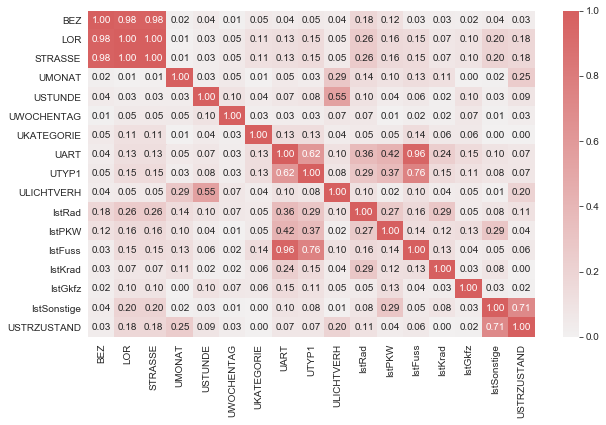

```python
co = custom_corr(data.drop(['OBJECTID','LINREFX', 'LINREFY', 'XGCSWGS84', 'YGCSWGS84'],
                           axis=1),
                 cramers_v)

sns.heatmap(co,
            annot=True,
            fmt='.2f',
            cmap=sns.light_palette(sns_c[3], as_cmap=True))
```

### Injury Category and Light Conditions

Category explanations: https://www.statistik-berlin-brandenburg.de/opendata/AfSBBB_BE_LOR_Strasse_Strassenverkehrsunfaelle_2019_Datensatzbeschreibung.pdf

```python
data.UKATEGORIE.value_counts()/data.shape[0]
```

```
3    0.849440
2    0.148021
1    0.002539
Name: UKATEGORIE, dtype: float64
```

```python
#Swapping injury levels to make the most severe the highest int
data.UKATEGORIE = data.UKATEGORIE.map({1:'deadly',
                                       2:'severe',
                                       3:'light'})
```

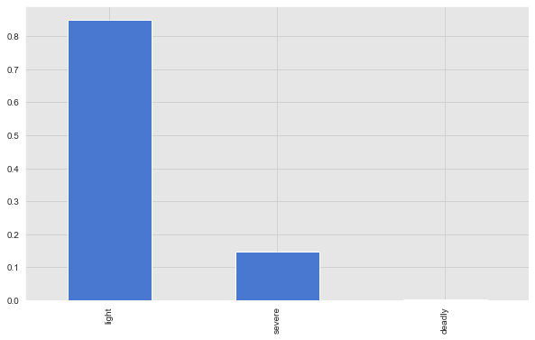

```python
(data.UKATEGORIE.value_counts()/data.shape[0]).plot(kind='bar')
```

```
Columns = Light conditions: 0 = Daylight , 1 = Dusk/Dawn , 2 = Darkness
```

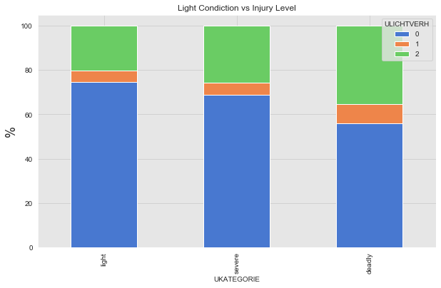

```python
print('Columns = Light conditions: 0 = Daylight , 1 = Dusk/Dawn , 2 = Darkness')
order = ['light', 'severe', 'deadly']
(pd.crosstab(data.UKATEGORIE, data.ULICHTVERH, normalize='index').mul(100)) \
    .loc[order] \
    .plot(kind='bar', stacked=True)
plt.title('Light Condiction vs Injury Level')
_ = plt.ylabel('%', fontsize=18)
```

Most accidents result in minor injuries, with a proportion of approx 85%, severe injuries around 15% and deadly accidents account for 0.2% of accidents.

For each injury category, most accidents happen during daytime, with only a few at dusk/dawn and at night, the ratio lies between 20% and 35%. I suppose, this effect is mostly due to the higher traffic amount during daytime and due to dusk/dawn only lasting for a small amount of time each day.

Notable is the increase in the proportion of deadly accidents from 20% during the day, to 35% at night. So although the traffic is probably much lower during the night, the chance of an accident being deadly increases significantly, pointing at the light conditions being a large factor in the severety of an accident.

### Injury Category and Involved Vehicles

```python
data.loc[:,['IstRad', 'IstPKW',
    'IstFuss', 'IstKrad', 'IstGkfz', 'IstSonstige']] \
    .sum(axis=1) \
    .value_counts()
```

```
2    6998
1    6228
0     132
3      32
dtype: int64
```

Amount of vehicles involved doesnt exceed 3.

```python
df = data.loc[:,['ULICHTVERH', 'UKATEGORIE', 'IstRad', 'IstPKW',
    'IstFuss', 'IstKrad', 'IstGkfz', 'IstSonstige']]
```

```python
df.iloc[:,2:].IstSonstige.value_counts() #Issues with IstSonstige feature.
```

```
0              11508
1               1881
812083,7893        1
Name: IstSonstige, dtype: int64
```

```python
df.loc[~df.IstSonstige.isin(['0','1','2','3'])] #Wrong value.
```

|  | ULICHTVERH | UKATEGORIE | IstRad | IstPKW | IstFuss | IstKrad | IstGkfz | IstSonstige |
| --- | --- | --- | --- | --- | --- | --- | --- | --- |
| 11893 | 0 | light | 0 | 1 | 0 | 0 | 0 | 812083,7893 |

```python
#Impute with most frequent value.
df.loc[11893,'IstSonstige'] = '0'
df.IstSonstige = df.IstSonstige.astype(int)
```

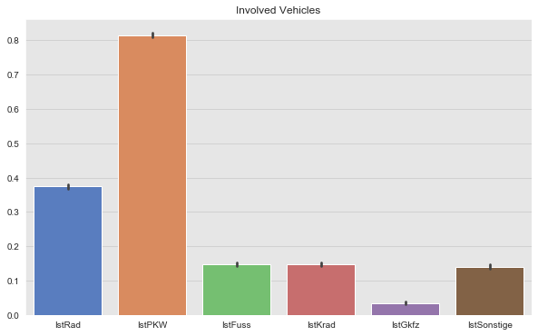

```python
f,ax=plt.subplots()
df.iloc[:,2:] \
    .pipe((sns.barplot,'data'))
_=ax.set(title='Involved Vehicles')
```

```python
vehicles = [
    'IstRad', 'IstPKW',
    'IstFuss', 'IstKrad',
    'IstGkfz', 'IstSonstige'
    ]
```

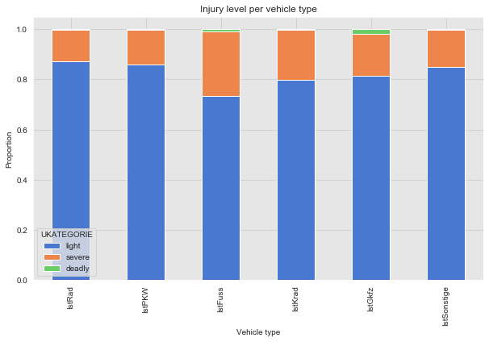

```python
df.groupby(['UKATEGORIE'], as_index=True) \
    .agg('sum') \
    .drop('ULICHTVERH',axis=1) \
    .div(df.loc[:,vehicles].sum(axis=0)) \
    .T \
    .loc[:,order] \
    .plot(kind='bar', stacked=True)
plt.title('Injury level per vehicle type')
plt.xlabel('Vehicle type')
_=plt.ylabel('Proportion')
```

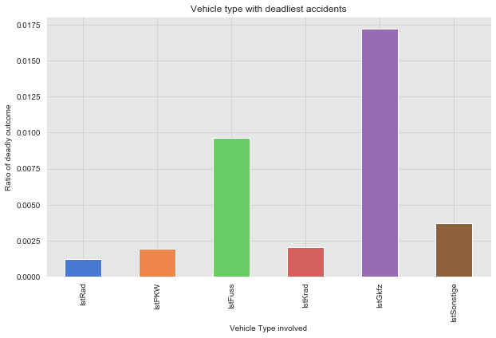

```python
df.loc[df.UKATEGORIE == "deadly", vehicles] \
    .sum(axis=0) \
    .div(df.loc[:, vehicles].sum(axis=0)) \
    .plot(kind='bar', color=sns_c)
plt.title('Vehicle type with deadliest accidents')
plt.xlabel('Vehicle Type involved')
plt.ylabel('Ratio of deadly outcome')
```

Since more than 1 vehicle can be involved in an accident, we can find out, which combination causes the most accidents.

```python
#More than 1 vehicle type can be involved so let's include the combinations.
from itertools import combinations
list(combinations(vehicles,2))
```

```
[('IstRad', 'IstPKW'),
 ('IstRad', 'IstFuss'),
 ('IstRad', 'IstKrad'),
 ('IstRad', 'IstGkfz'),
 ('IstRad', 'IstSonstige'),
 ('IstPKW', 'IstFuss'),
 ('IstPKW', 'IstKrad'),
 ('IstPKW', 'IstGkfz'),
 ('IstPKW', 'IstSonstige'),
 ('IstFuss', 'IstKrad'),
 ('IstFuss', 'IstGkfz'),
 ('IstFuss', 'IstSonstige'),
 ('IstKrad', 'IstGkfz'),
 ('IstKrad', 'IstSonstige'),
 ('IstGkfz', 'IstSonstige')]
```

```python
# Count the occuring vehicle combinations.
df_comb = df.copy()
count_comb = []

# 2 involved vehicles
for comb in combinations(vehicles, 2):
    c = df_comb.loc[(df_comb[comb[0]] == 1) &
                   (df_comb[comb[1]] == 1)
                   ].shape[0]
    count_comb.append((comb,c))

# 3 involved vehicles
for comb in combinations(vehicles, 3):
    c = df_comb.loc[(df_comb[comb[0]] == 1) &
                   (df_comb[comb[1]] == 1) &
                   (df_comb[comb[2]] == 1)
                   ].shape[0]
    count_comb.append((comb,c))

# 1 involved vehicle
for v in vehicles:
    others = set(vehicles).difference(set([v]))
    others = [others.pop() for i in range(len(others))]
    c = df_comb.loc[(df_comb[v]==1) &
                   (df_comb[others[0]] == 0) &
                   (df_comb[others[1]] == 0) &
                   (df_comb[others[2]] == 0) &
                   (df_comb[others[3]] == 0) &
                   (df_comb[others[4]] == 0)
                   ].shape[0]
    count_comb.append((v,c))
```

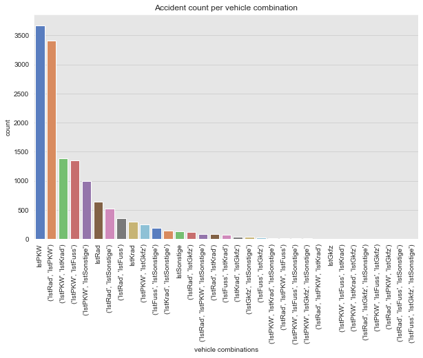

```python
pd.DataFrame(count_comb,columns=['vehicles', 'count']) \
    .set_index('vehicles') \
    .sort_values('count', ascending=False) \
    .query('count > 0') \
    .T \
    .pipe((sns.barplot,'data'), palette=sns_c)
plt.xticks(rotation=90)
plt.xlabel('vehicle combinations')
plt.title('Accident count per vehicle combination')
_=plt.ylabel('count')
```

Which combination is causing the deadly accidents?

```python
df_comb = df.query('UKATEGORIE == \'deadly\'') # Look only at deadly.
count_comb = []

# 2 involved vehicles
for comb in combinations(vehicles, 2):
    c = df_comb.loc[(df_comb[comb[0]] == 1) &
               (df_comb[comb[1]] == 1)].shape[0]
    count_comb.append((comb,c))

# 3 involved vehicles
for comb in combinations(vehicles, 3):
    c = df_comb.loc[(df_comb[comb[0]] == 1) &
               (df_comb[comb[1]] == 1) &
               (df_comb[comb[2]] == 1)].shape[0]
    count_comb.append((comb,c))

# 1 involved vehicle
for v in vehicles:
    others = set(vehicles).difference(set([v]))
    others = [others.pop() for i in range(len(others))]
    c = df_comb.loc[(df_comb[v]==1) &
               (df_comb[others[0]] == 0) &
               (df_comb[others[1]] == 0) &
               (df_comb[others[2]] == 0) &
               (df_comb[others[3]] == 0) &
               (df_comb[others[4]] == 0)
              ].shape[0]
    count_comb.append((v,c))
```

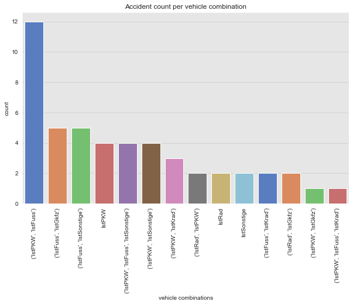

```python
pd.DataFrame(count_comb,columns=['vehicles','count']) \
    .set_index('vehicles') \
    .sort_values('count',ascending=False) \
    .query('count > 0') \
    .T \
    .pipe((sns.barplot,'data'),palette=sns_c)
plt.xticks(rotation=90)
plt.xlabel('vehicle combinations')
plt.title('Accident count per vehicle combination')
_=plt.ylabel('count')
```

We see that pedestrians (IstFuss) are in highest danger of experiencing a deadly accident, as this category is included in the top 3 combinations.

### Geographical analysis

```python
#Turn district numbers into actual names.
bez_names = (
    'Mitte','Friedrichshain-Kreuzberg','Pankow',
    'Charlottenburg-Wilmersdorf','Spandau','Steglitz-Zehlendorf',
    'Tempelhof-Schöneberg','Neukölln','Treptow-Köpenick',
    'Marzahn-Hellersdorf','Lichtenberg','Reinickendorf'
    )

bez_map = dict(enumerate(bez_names,1))
data.BEZ = data.BEZ.map(bez_map)
```

```python
#Adding feature that adds accident amount in the street the accident happened.
df = data.assign(count_str=lambda x: x.groupby(['STRASSE'], as_index=False)
                 .OBJECTID.transform('count'))
```

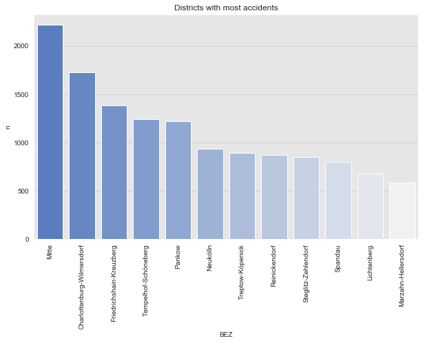

```python
g = df.groupby('BEZ',as_index=False) \
    .agg(n=('OBJECTID','count')) \
    .sort_values('n',ascending=False) \
    .pipe((sns.barplot,'data'),
         x='BEZ',
         y='n',
         palette=sns.light_palette(sns_c[0],12, reverse=True))
plt.xticks(rotation=90)
_=plt.title('Districts with most accidents')
```

```python
#Accidents on street level.
print('Max accidents:',df.STRASSE.value_counts().max())
print('Min accidents:',df.STRASSE.value_counts().min())
print('Mean accidents:',df.STRASSE.value_counts().mean())
print('Median accidents:',df.STRASSE.value_counts().median())
print('Std accidents:',df.STRASSE.value_counts().std())
```

```
Max accidents: 177
Min accidents: 1
Mean accidents: 30.36281179138322
Median accidents: 24.0
Std accidents: 25.68072986932644
```

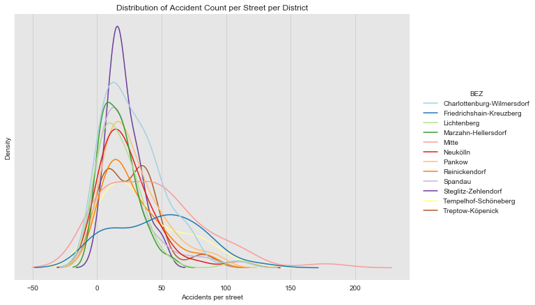

```python
#f,ax=plt.subplots(figsize=(10,7))
df.groupby(['BEZ','STRASSE'],as_index=False) \
    .agg(n=('OBJECTID','count')) \
    .pipe((sns.displot,'data'),
          kind='kde',
          hue='BEZ',
          palette='Paired',
          x='n',
          height=6,
          aspect=1.5)
plt.xlabel('Accidents per street')
plt.yticks([])
_=plt.title('Distribution of Accident Count per Street per District')
```

If we take all accidents in a street and take the ratio of severe and deadly injuries to the total of accidents, the ratio can be interpreted as a meassure of severity or deadliness in that street.

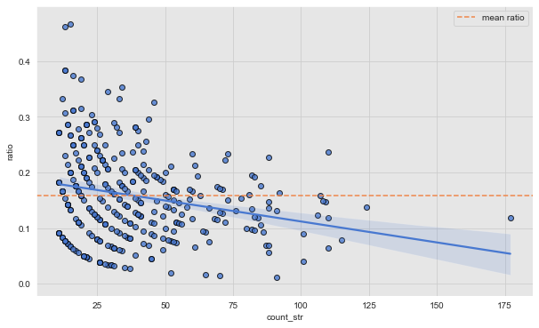

```python
f,ax = plt.subplots()
street_df = df.assign(count_str=lambda x: x.groupby(['STRASSE'], as_index=False)
    .OBJECTID.transform('count')) \
    .query('UKATEGORIE != \'light\' & count_str > 10') \
    .groupby(['BEZ','STRASSE'], as_index=False) \
    .agg(bad_inj=('UKATEGORIE', 'count'),
         count_str=('count_str', 'first')) \
    .assign(ratio=lambda x: x['bad_inj'] / x['count_str'])

street_df.pipe((sns.regplot, 'data'),
              x='count_str',
              y='ratio',
              color=sns_c[0],
              fit_reg=True,
              scatter=True,
              scatter_kws={'edgecolor':'black'})
mean = street_df.ratio.mean()
ax.axhline(y=mean, color=sns_c[1], label='mean ratio', linestyle='--')
plt.legend(loc='upper right')
```

Only streets with more than 10 accidents are used, to make sure that we ahave statistical significance of the ratio. Plotting all the street ratios shows a significant downward trend of ratios with growing accident count in the street, even below the overall mean, which means that mere regression to the mean is unlikely.

Doing the same analysis for each district respectively shows the districts that show this trend respectively.

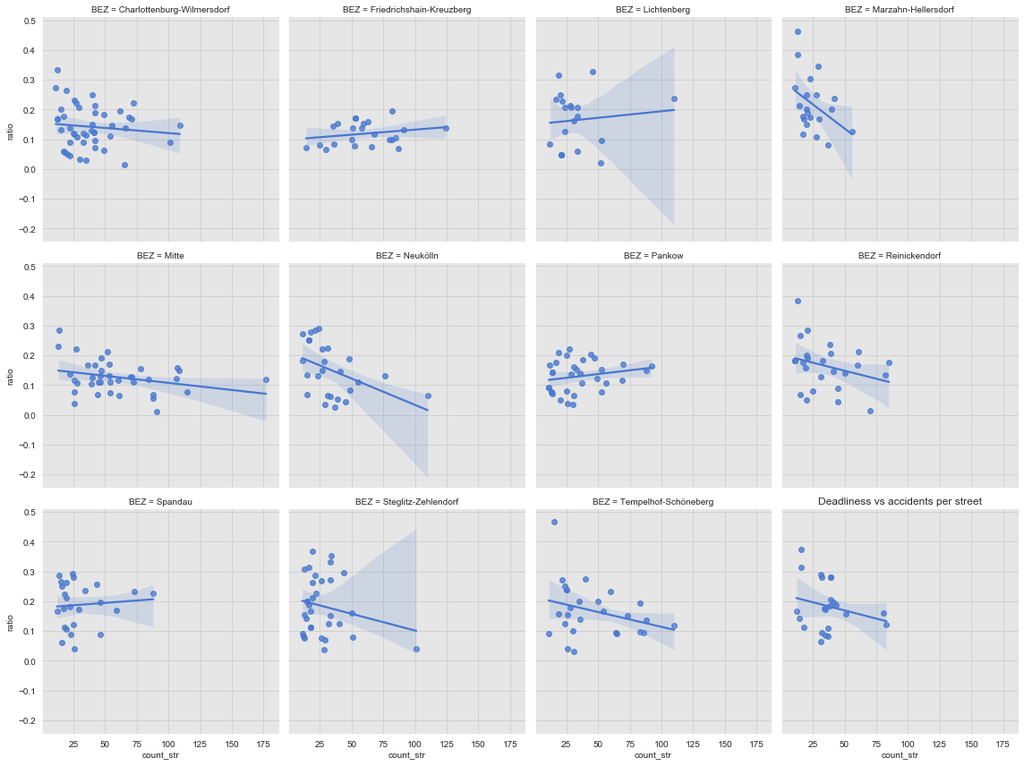

```python
g = street_df \
    .pipe((sns.FacetGrid,'data'),
         col='BEZ',
         col_wrap=4,
         height=4)
g.map(sns.regplot, 'count_str', 'ratio')
_=plt.title('Deadliness vs accidents per street')
```

```python
risk_streets = street_df.query('ratio > 0.2 & count_str > 50') \
    .STRASSE

print(risk_streets)
```

```
29           Park Ruhwald
84          Rüdigerstraße
126       Invalidenstraße
230          Wittenau Süd
236       Borkumer Straße
238    Carl-Schurz-Straße
291        Dennewitzplatz
Name: STRASSE, dtype: object
```

First we plot all accidents over a map of Berlin.

```python
p ='./accidents/geodata/Bezirke_-_Berlin-shp/Berlin_Bezirke.shp'
border_map = gpd.read_file(p)
border_map = border_map.to_crs(epsg=4326)
```

```python
df['long'] = df.XGCSWGS84.apply(lambda x: float(x.replace(',', '.')))
df['lat'] = df.YGCSWGS84.apply(lambda x: float(x.replace(',', '.')))
```

```python
crs = {'init':'EPSG:4326'}
geometry = [Point(xy) for xy in zip(df.long,df.lat)]
geo_df = gpd.GeoDataFrame(df,
                         crs='EPSG:4326',
                         geometry = geometry)
```

```python
geo_df.drop(geo_df.loc[df.long>50].index,axis=0,inplace=True)
geo_df.UKATEGORIE = geo_df.UKATEGORIE.astype(str)
```

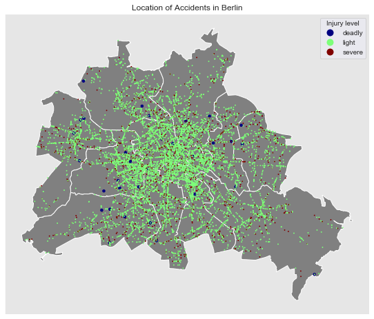

```python
f,ax=plt.subplots(figsize=(15,8))
sns.set_style('dark')
border_map.plot(color='grey',ax=ax)
geo_df.plot(column='UKATEGORIE',
            marker='.',
            ax=ax,
            markersize=np.where(
                geo_df['UKATEGORIE'] == 'deadly',
                50,
                3
                ),
            legend=True,
            legend_kwds={'title':'Injury level'},
            cmap='jet')

plt.xticks([])
plt.yticks([])
plt.title('Location of Accidents in Berlin')
sns.despine()
```

Now we'll see where the high risk streets are located.

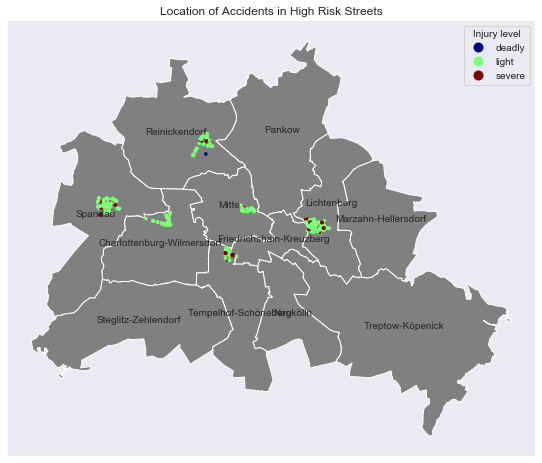

```python
f,ax=plt.subplots(figsize=(15,8))
border_map.plot(color='grey', ax=ax)
geo_df.loc[geo_df.STRASSE.isin(risk_streets)] \
    .plot(column='UKATEGORIE',
          marker='.',
          ax=ax,
          legend=True,
          legend_kwds={'title':'Injury level'},
          cmap='jet')

border_map.apply(lambda x: ax.annotate(s=x.Gemeinde_n,
                                       xy=x.geometry.centroid.coords[0],
                                       ha='center',
                                       fontsize=10),
                 axis=1)
plt.xticks([])
plt.yticks([])
plt.title('Location of Accidents in High Risk Streets')
sns.despine()
```

### Analysis of Time Data

```python
sns.set_style('darkgrid',
             rc={'axes.facecolor': '.9',
                 'grid.color': '.8'})
```

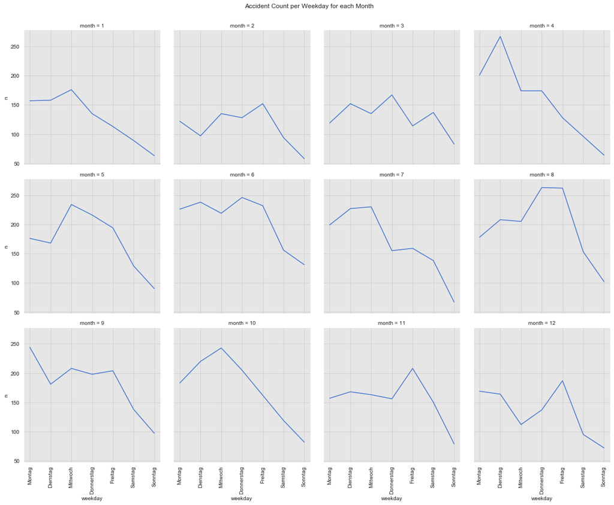

```python
days=['Montag','Dienstag','Mittwoch','Donnerstag','Freitag','Samstag','Sonntag']
g = data.groupby(['UMONAT','UWOCHENTAG'],as_index=True) \
    .agg(n=('OBJECTID','count')) \
    .reindex(pd.MultiIndex.from_product([range(1,13), days])) \
    .reset_index() \
    .rename(columns={'level_0':'month','level_1':'weekday'}) \
    .pipe((sns.FacetGrid),
         col='month',
         col_wrap=4,
         height=4)
g.map(sns.lineplot,'weekday','n')
g.fig.suptitle('Accident Count per Weekday for each Month', y=1.03);
for ax in g.axes:
    ax.tick_params(axis='x', labelrotation=90)
```

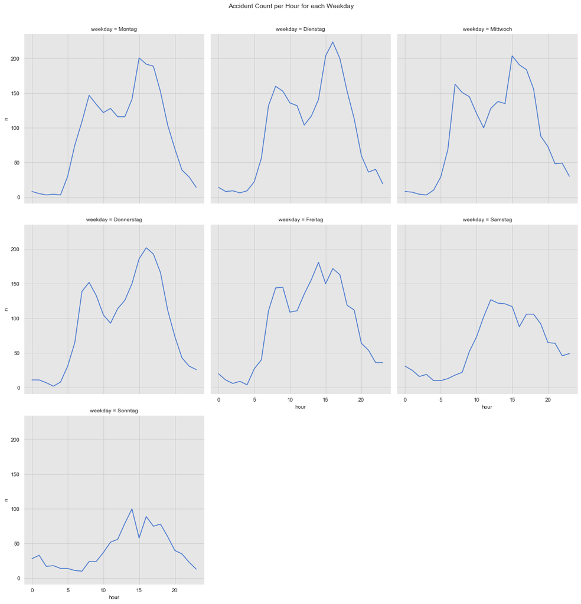

```python
g = data.groupby(['UWOCHENTAG','USTUNDE'],as_index=True) \
    .agg(n=('OBJECTID','count')) \
    .reindex(pd.MultiIndex.from_product([days,range(24)])) \
    .reset_index() \
    .rename(columns={'level_0':'weekday','level_1':'hour'}) \
    .pipe((sns.FacetGrid),
         col='weekday',
         col_wrap=3,
         height=5)
g.map(sns.lineplot,'hour','n')
g.fig.suptitle('Accident Count per Hour for each Weekday', y=1.03);
```

Most accidents happen during the week with 2 peaks per day during the rush hours. This is not surprising as more traffic means more potential for accidents. During the weekends, the peak is almost 50% lower than during the week. Also the peak for the afternoon rushhour is consistently higher than for the morning rush hour.

### Street condition

```python
df = data.copy()
```

Lets first map the real condition names onto the data:

```python
df.USTRZUSTAND = df.USTRZUSTAND.map({'0':'dry',
                                     '1':'wet',
                                     '2':'snow/ice'})
```

Let's see how the street condiction affects the injury level of accidents. Most accidents happen in dry weather, which doesnt tell us much, because we are counting absolute numbers. Since most days are dry, most accidents will happen in dry weather.

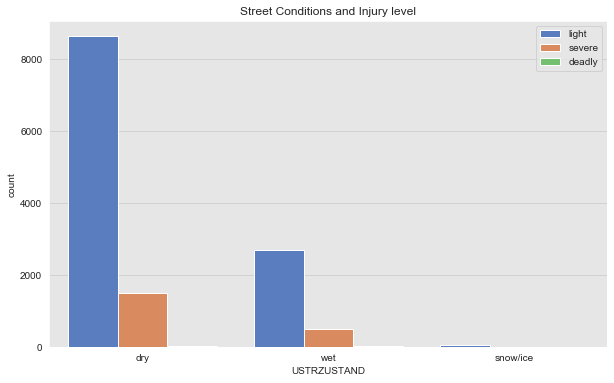

```python
f,ax = plt.subplots()
sns.countplot(data=df,
              x='USTRZUSTAND',
              hue='UKATEGORIE',
              order=['dry','wet','snow/ice'],
              ax=ax)
ax.set(title='Street Conditions and Injury level')
_=ax.legend(loc='upper right')
```

To see how much the street condition is affecting injuries, we have to look at the proportion of the injury levels vs the street conditions. Interestingly, the rations are very constant, with the severe injury level even dropping slightly for snow/ice condition. Maybe due to people driving naturally slower.

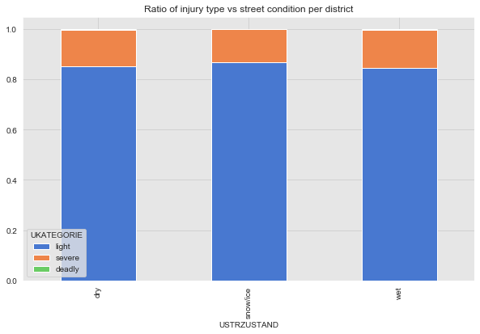

```python
cmap=ListedColormap(sns_c.as_hex(),N=3)
pd.crosstab(index=df.USTRZUSTAND,columns=df.UKATEGORIE,
            values=df.OBJECTID,aggfunc='count',normalize='index') \
    .fillna(0) \
    .loc[:,order] \
    .plot(kind='bar', stacked=True,cmap=cmap)
plt.title('Ratio of injury type vs street condition per district')
```

Are there some differences on a district level?

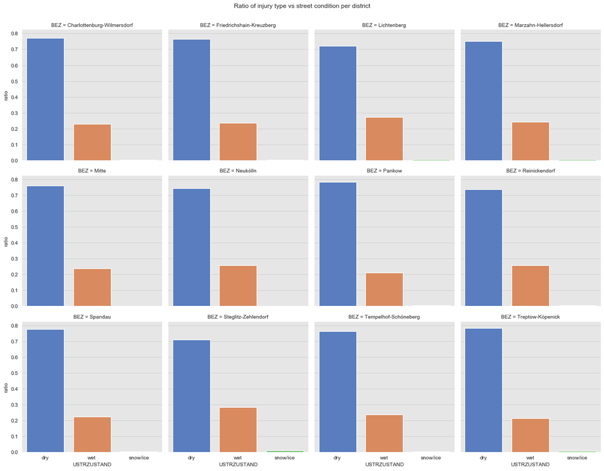

```python
g = df.assign(bez_cnt=lambda x: x.groupby(['BEZ'],as_index=True)
    .OBJECTID \
    .transform('count')) \
    .groupby(['BEZ','USTRZUSTAND'],as_index=False) \
    .agg(n=('OBJECTID','count'),sum=('bez_cnt','first')) \
    .assign(ratio=lambda x: x['n'].div(x['sum'])) \
    .pipe(sns.FacetGrid,
         col='BEZ',
         col_wrap=4,
         height=4,
         )
g.map(sns.barplot,'USTRZUSTAND','ratio',
      order=['dry','wet','snow/ice'],
      palette=sns_c
      )
_=g.fig.suptitle('Ratio of injury type vs street condition per district', y=1.03)
```

```python
df.assign(str_cnt=lambda x: x.groupby(['STRASSE'])
    .OBJECTID \
    .transform('count')) \
    .groupby(['STRASSE','USTRZUSTAND'],as_index=False) \
    .agg(n=('OBJECTID','count'),
         total=('str_cnt','first')) \
    .assign(ratio = lambda x: x['n']/x['total']) \
    .query('USTRZUSTAND != \'dry\'') \
    .groupby('STRASSE') \
    .agg({'ratio':'sum','total':'first'}) \
    .sort_values(by='ratio',ascending=False) \
    [:30]
```

| STRASSE | ratio | total |
| --- | --- | --- |
| Hundekehle | 1.000000 | 1 |
| Griesingerstraße | 1.000000 | 1 |
| Gewerbegebiet Ederstraße | 1.000000 | 1 |
| Lübecker Straße | 0.800000 | 5 |
| Spindlersfeld | 0.750000 | 4 |
| Lichterfelde Süd | 0.727273 | 11 |
| Gensinger Straße | 0.666667 | 6 |
| Stralauer Halbinsel | 0.600000 | 5 |
| Düppel | 0.600000 | 5 |
| Schmöckwitz/Rauchfangswerder | 0.571429 | 7 |
| Treuenbrietzener Straße | 0.545455 | 11 |
| Angerburger Allee | 0.500000 | 2 |
| Flatowallee | 0.500000 | 4 |
| Hohenschönhausener Straße | 0.500000 | 2 |
| Zingster Straße West | 0.500000 | 8 |
| Schleipfuhl | 0.500000 | 2 |
| Zingster Straße Ost | 0.500000 | 2 |
| Teltower Damm | 0.470588 | 34 |
| Hausotterplatz | 0.461538 | 13 |
| Lankwitz Süd | 0.461538 | 13 |
| Mellerbogen | 0.454545 | 11 |
| Landsberger Allee | 0.454545 | 22 |
| Savignyplatz | 0.450000 | 20 |
| Mahlsdorf Nord | 0.450000 | 20 |
| Hellersdorfer Promenade | 0.444444 | 9 |
| Frankfurter Allee Süd | 0.428571 | 7 |
| Victoriastadt | 0.428571 | 21 |
| Feuerbachstraße | 0.423077 | 26 |
| Malchower Weg | 0.421053 | 19 |
| Rollbergesiedlung | 0.421053 | 19 |

### Accident type

Category explanations: https://www.statistik-berlin-brandenburg.de/opendata/AfSBBB_BE_LOR_Strasse_Strassenverkehrsunfaelle_2019_Datensatzbeschreibung.pdf

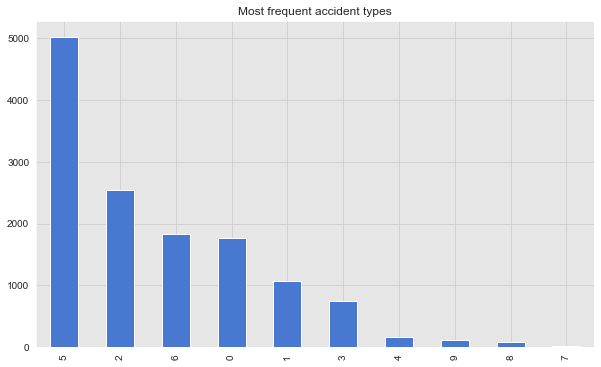

```python
df.UART.value_counts().plot(kind='bar')
plt.title('Most frequent accident types')
```

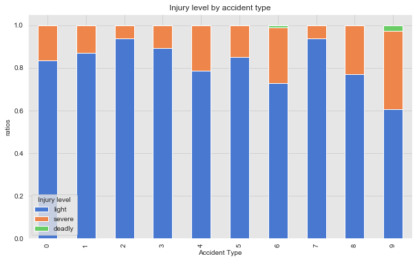

```python
cmap=ListedColormap(sns_c.as_hex(),N=3)
pd.crosstab(index=df.UART,
            columns=df.UKATEGORIE,
            values=df.OBJECTID,
            aggfunc='count',
            normalize='index') \
    .loc[:,order] \
    .plot(kind='bar',
          stacked=True,
          xlabel='Accident Type',
          title='Injury level by accident type',
          cmap=cmap)
plt.legend(title='Injury level')
_=plt.ylabel('ratios')
```

Accidents types with the highest proportion of severe injury and death (level 2 & 3) are code 4, 6, 8 and 9. Those codes stand for:

4 = Head-on collision with oncoming vehicle

6 = Collision with vehicle and pedestrian

8 = Getting off the road to the RIGHT side

9 = Getting off the road to the LEFT side

The question arises again, if there are some vehicle types that are prone to a specific type of accident. To show these connection, I used a correlation heatmap, using cramers_v as correlation function:

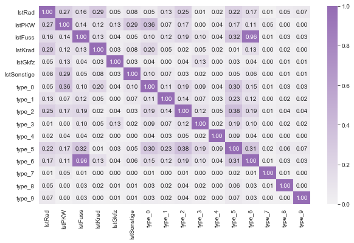

```python
co = custom_corr(
    pd.concat(
        [df.loc[:,vehicles],
        (pd.get_dummies(df.UART, prefix='type'))],
        axis=1).astype(str),
    cramers_v
    )
sns.heatmap(co,annot=True,fmt='.2f', cmap=sns.light_palette(sns_c[4], as_cmap=True))
```

Small correlations can be seen between Bikes and accident type 2, which stands for collision with driving/waiting vehicle in front, between bikes and pedestrians with type 5, which stands for collision with crossing/turning vehicle and the highest correlation is between pedestrian and type 6 which means collision with pedestrian involved (the correlation is obvious).

### Conclusions

Almost half of the deadly accidents happen during dusk/dawn or night time, while during daytime, the vast majority causes light injury. In most accidents, cars are involved, which is not surprising due to the traffic volume they cause.

The distribution of the accident count on a street level, shows quite a few outliers that are responsible for a large amount of accidents. Interestingly, the average injury level seems to decrease with the amount of accidents happening in a specific street. There are a handful of streets that have a high accident count with high chance of severe and deadly injury however.

The amount of accidents is high during weekdays and decreaes a bit during the winter months. On a daily level, there are 2 spikes during the rush hour times during working days, the second rushhour being a bit more accident prone.

The analysis of type of accidents confirms earlier findings. The most dangerous are collisions with pedestrians. Head on collisiosn are naturally also dangerous. Interestingly, the deadliest type is coming of the road on the left side, which is significantly more deadly than getting of to the right side. There is also a correlation between bicycle involvement and collisions with waiting/halting traffic.

Possibility for future analysis could involve the combination of the data with traffic data, to account for the fact that there are large discrepancies between traffic volumes. The analysis is negatively affected by the fact, that there is no specific time stamp for the accidents, but only general time information, like month and weekday. A more fine grained time feature would reveal more insights.